# Project: Ford GoBike Trip

### Investigation Overview

I will investigate the data in the locations that have the most density as this will help in marketing specially in ( customer targeting & offers ) to increase sales .

### Dataset Overview

There are 174,898 trips recorded with complete data in the dataset , these data divided to four dimensions ( trip time , start and end location , bike data and user data ). the data differ between numeric and categorical .

#### What are most 15 start & end stations that have high customers density ?

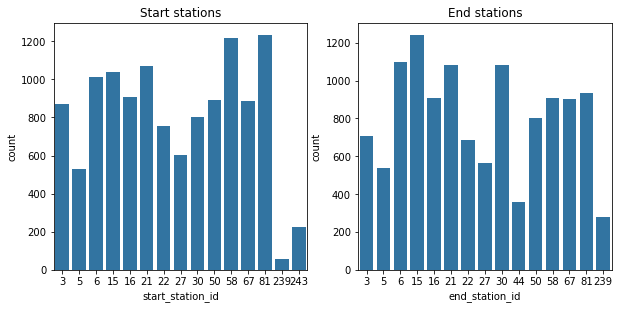

#### What are customers characteristics ?

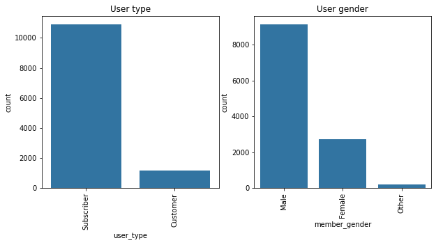

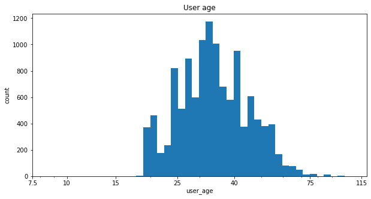

#### Customers characteristics

The users characterisitics in common even in all locations or the most density ( Type : Subscribers , Gender : Male , Age : from 20 to 40 )

### What is the common trip duration ?

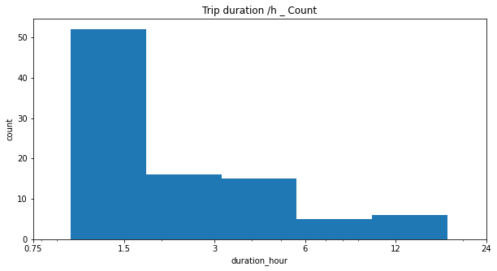

## let's dig deep in the common customers characteristics and trip duration for each station even start or end to check if there is any variance.

### What are user type and age for start and end locations ?

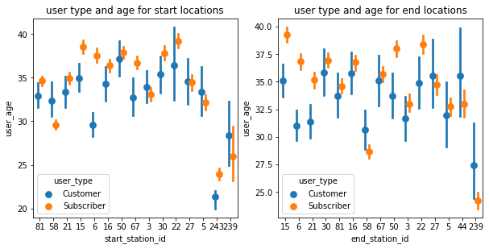

### What are user gender and age for start and end locations ?

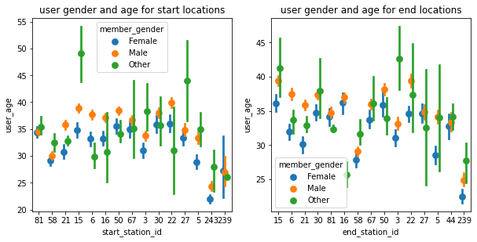

### To Conclude :

we checked and find these conclusion throw our journey thus we could get use of these by :

- For low density customers stations we can use these targeted customers in marketing and offers which will increase the revenue of the company.
- For high density customers stations if there still work capicity available we can increase revenues by 2 ways :  
  1- Offers for females between 20 to 40 years even for subscriber or customer type.  
  2- More engagement for targeted customer with above characteristics .

## Tahnks :)